# opendataformat

## Export to the Open Data Format: `write_odf()`

To save a dataset as odf-file, we can use the `write_odf()` function. Let’s assume we want to save the first four columns of our dataset as a new odf-file. We use the `write_odf()` function and indicate the r-dataframe and the file name (and location if it).

```r
write_odf(
  x = df[, 1:4],
  file = "../df_1_4.odf.zip"
)

#or :
df_14 <- df[, 1:4]
write_odf(
  x = df[, 1:4],
  file = "df_1_4.odf.zip"
)
```

```xml
<?xml version='1.0' encoding='utf-8'?>
<codeBook xmlns:xsi="http://www.w3.org/2001/XMLSchema-instance" xsi:schemaLocation="ddi:codebook:2_5 http://www.ddialliance.org/Specification/DDI-Codebook/2.5/XMLSchema/codebook.xsd" xmlns="ddi:codebook:2_5" version="2.5">
    <fileDscr>
        <fileTxt>
            <fileName>bap</fileName>
            <fileCont xml:lang="en">The data were collected as part of the SOEP-Core study using the questionnaire "Living in Germany - Survey 2010 on the social situation - Personal questionnaire for all. This questionnaire is addressed to the individual persons in the household. A view of the survey instrument can be found here: https://www.diw.de/documents/dokumentenarchiv/17/diw_01.c.369781.de/soepfrabo_personen_2010.pdf</fileCont>
            <fileCont xml:lang="de">Die Daten wurden im Rahmen der Studie SOEP-Core mittels des Fragebogens „Leben in Deutschland – Befragung 2010 zur sozialen Lage - Personenfragebogen für alle“ erhoben. Dieser Fragebogen richtet sich an die einzelnen Personen im Haushalt. Eine Ansicht des Erhebungsinstrumentes finden Sie hier: https://www.diw.de/documents/dokumentenarchiv/17/diw_01.c.369781.de/soepfrabo_personen_2010.pdf</fileCont>
            <fileCitation>
                <titlStmt>
                    <titl xml:lang="en">Data from individual questionnaires 2010</titl>
                    <titl xml:lang="de">Daten vom Personenfragebogen 2010</titl>
                </titlStmt>
            </fileCitation>
        </fileTxt>
        <notes>
            <ExtLink URI="https://paneldata.org/soep-core/data/bap" />
        </notes>
    </fileDscr>
    <dataDscr>
        <var name="bap87">
            <labl xml:lang="en">Current Health</labl>
            <labl xml:lang="de">Gesundheitszustand gegenwärtig</labl>
            <txt xml:lang="en">Question: How would you describe your current health?</txt>
            <txt xml:lang="de">Frage: Wie würden Sie Ihren gegenwärtigen Gesundheitszustand beschreiben?</txt>
            <notes>
                <ExtLink URI="https://paneldata.org/soep-core/data/bap/bap87" />
            </notes>
            <varFormat type="numeric" />
            <catgry>
                <catValu>-2</catValu>
                <labl xml:lang="en">Does not apply</labl>
                <labl xml:lang="de">trifft nicht zu</labl>
            </catgry>
            <catgry>
                <catValu>-1</catValu>
                <labl xml:lang="en">No Answer</labl>
                <labl xml:lang="de">keine Angabe</labl>
            </catgry>
            <catgry>
                <catValu>1</catValu>
                <labl xml:lang="en">Very good</labl>
                <labl xml:lang="de">Sehr gut</labl>
...
```

The data.csv file now includes just four columns:

```
"bap87","bap9201","bap9001","bap9002"
4,-2,1,-1
3,5,-2,1
,-1,-1,2
1,9,-2,2
-1,4,2,3
3,4,-1,4
1,9,2,-1
...
```

If you wish to export only the metadata for documentation or archiving purposes, you can achieve this by setting the argument `export_data=FALSE`. By doing so, the resulting directory or zip file will solely contain the metadata XML file, excluding the data CSV file. This allows you to specifically capture and preserve the metadata without including the actual data, providing a solution for documentation or archiving needs.

```r
write_odf(
  x = df,
  file = "../df_metadata.odf.zip",
  export_data = FALSE
)
```

If you wish to export the dataset with the metadata only in one or some languages, set the languages argument to `languages=c("en")`. Default: `languages="all"`

```r
write_odf(
  x = df,
  file = "../df_en.odf.odf.zip",
  languages = "en"
)
```

By default, languages is set to `languages="all"`. You can also define a list of languages to be exported:

```r
write_odf(
  x = df,
  file = "../df_en_de.odf.odf.zip",
  languages = c("en", "de")
)
```

## Create ODF tibbles and convert data frames to odf_tbl: `as_odf_tbl()`

To convert a data frame to an ODF tibble in R, the `opendataformat`package provides the `as_odf_tbl() function`. It transforms a dataframe (or any subclass) object to an Open Data Format tibble (an object of the odf_tbl class). The metadata in the data frame has to be stored in the attributes according to the odf_tbl framework:

Regarding the dataset metadata, the dataset name is stored in the `name`-attribute, a URL can be stored in the `url`-attribute. The multilingual labels and descriptions are stored in the `label_tag` and `description_tag`-attributes with the respective language tag. The dataset label in English language is stored in the `label_en`-attribute and the English description is stored in the `description_en`-attribute.

Regarding the variable metadata, the variable name is stored in the `name`-attribute, a URL can be stored in the `url`-attribute of each column, and the variable type (`numeric` or `character`) can be stored in the `type`-attribute. The multilingual labels, descriptions and value labels are stored in the `label_tag`, `description_tag`, and `labels_tag`-attributes with the respective language tag. The dataset label in English language is stored in the `label_en`-attribute and the English description is stored in the `description_en`-attribute. The value labels in English (a numeric vector with the labelled values and the value labels in the namespace) are stored in the `labels_en`-attribute of the column.

```r
#Create a data frame with four variables ind 5 rows
exampledata <- data.frame(id = 1:5,
                          name = c("Klaus", "Anna", "Rebecca",
                                   "Kevin", "Janina"),
                          age = c(55, 40, 19, 25, 60),
                          diagnosis = c(1,3,3,2,1))
# Add metadata for dataset according to ODF tibble framework.
attr(exampledata, "name") <- "patientdata"
attr(exampledata, "label_en") <- "Patient Data"
attr(exampledata, "description_en") <- "Patient database of the practice Dr. Sommer"
attr(exampledata, "url") <- "www.example.url.en"

# Add metadata for diagnosis variable with label, description and value labels.
attr(exampledata$id, "name") <- "id"
attr(exampledata$id, "label_en") <- "Patiend ID"
attr(exampledata$id, "description_en") <- "Practice Patiend ID"
attr(exampledata$diagnosis, "name") <- "diagnose"
attr(exampledata$diagnosis, "label_en") <- "Diagnosis"
attr(exampledata$diagnosis, "description_en") <- "Diagnosis patient last visit"
valuelabels_diagnosis <- 1:4
names(valuelabels_diagnosis) <- c("Covid", "Influenza", "Common cold", "Tonsillitis")
attr(exampledata$diagnosis, "labels_en") <- valuelabels_diagnosis
# use as_odf_bl to transform dataframe to an ODF tibble ('odf_tbl'-class object)
example_odf  <-  as_odf_tbl(exampledata)

# Display metadata of diagnosis Variable
docu_odf(example_odf$diagnosis, style = "print")
```

[output not shown]

# Let’s Analyse and Make Use of the Metadata

Now let’s see how we can use the metadata to better understand the data and make more informative plots.

### Frequency Table

```r
table(df$bap87, useNA = "ifany")

  -2   -1    1    2    3    4    5 <NA>
   3    2    2    2    5    2    3    1
```

As expected, the frequency table displays the occurrence count of each variable value. Now, let’s enhance the convenience of the frequency table by utilizing the value labels associated with the variables. To access the value labels, as explained in the preceding section, you can utilize the base R function `attributes()`. Let’s proceed to examine them now:

```r
attributes(df$bap87)$labels_en
Does not apply      No Answer      Very good           Good   Satisfactory
            -2             -1              1              2              3
          Poor            Bad
             4              5
```

```r
attributes(df$bap87)$labels_de
  trifft nicht zu      keine Angabe          Sehr gut               Gut
               -2                -1                 1                 2
Zufriedenstellend       Weniger gut          Schlecht
                3                 4                 5
```

```r
table(factor(df$bap87, labels = names(attributes(df$bap87)$labels_en)))

Does not apply      No Answer      Very good           Good   Satisfactory
             3              2              2              2              5
          Poor            Bad
             2              3
```

Alternatively you can use the getmetadata_odf()-function to get the value labels:

```r
table(factor(df$bap87,
             labels = names(getmetadata_odf(df$bap87, type = "valuelabels"))))
```

To display the data in a language other than the default one, let’s try German by appending the respective language code to the attribute name. For example, you can use $labels_de to access the German language labels and present the information accordingly.

```r
table(
  factor(
    df$bap87,
      labels = names(attributes(df$bap87)$labels_de)
    )
  )

  trifft nicht zu      keine Angabe          Sehr gut               Gut
                3                 2                 2                 2
Zufriedenstellend       Weniger gut          Schlecht
                5                 2                 3
```

Or using getmetadata_odf()-function:

```r
table(
  factor(
    df$bap87,
      labels = names(getmetadata_odf(df$bap87, type = "valuelabels",
                                     language = "de"))
    )
  )

  trifft nicht zu      keine Angabe          Sehr gut               Gut
                3                 2                 2                 2
Zufriedenstellend       Weniger gut          Schlecht
                5                 2                 3
```

## Merge ODF-Datasets:

To merge ODF-datasets you should use the left_join(), right_join(), full_join(), and inner_join() from the dplyr-package instead of the the merge()-function to keep the attributes with the metadata of the merged datasets.

```r
library(dplyr)
#similar to merge(df[,c(1:3,6)], df[,c(4:6)], by="name", all.x=T, all.y=F)
merged_df <- left_join(df[, c(1:3, 6)], df[, c(4:6)], by = "name")
#or
merged_df <- left_join(df[, c(1:3, 6)], df[, c(4:6)])
```

### Recoding a Variable

We want to display the table with only valid answers. Therefore, we set the values `-2` and `-1` to `NA`. Because we do not want to overwrite the original variable, we generate a new one:

```r
bap87_rec <- df$bap87
```

We check the attributes of the metadata and notice they are also copied from the original variable to the new one:

```r
attributes(bap87_rec)
$name
[1] "bap87"

$label_en
[1] "Current Health"

$label_de
[1] "Gesundheitszustand gegenwärtig"

$description_en
[1] "Question: How would you describe your current health?"

$type
[1] "numeric"

$url
[1] "https://paneldata.org/soep-core/data/bap/bap87"

$labels_en
Does not apply      No Answer      Very good           Good   Satisfactory
            -2             -1              1              2              3
          Poor            Bad
             4              5

$labels_de
  trifft nicht zu      keine Angabe          Sehr gut               Gut
               -2                -1                 1                 2
Zufriedenstellend       Weniger gut          Schlecht
                3                 4                 5

$languages
[1] "en" "de"

$lang
[1] "en"

$label
[1] "Current Health"
```

Now we can set the negative values to NA:

```r
for (row in seq(1, length(bap87_rec))) {
  if (!is.na(bap87_rec[row]) && bap87_rec[row] <= -1) {
    bap87_rec[row] <- NA
  }
}

table(bap87_rec, useNA = "ifany")
bap87_rec
   1    2    3    4    5 <NA>
   2    2    5    2    3    6
```

We notice that the copied values and value labels do not fit anymore:

```r
attributes(bap87_rec)$labels_en
Does not apply      No Answer      Very good           Good   Satisfactory
            -2             -1              1              2              3
          Poor            Bad
             4              5
```

To change that, we’ll copy positions `3` to `7`, retaining the desired range of values and their respective value labels.

```r
attributes(bap87_rec)$labels_en <-
  unname(attributes(df$bap87)$labels_en)[3:7] # values
names(attributes(bap87_rec)$labels_en) <-
  names(attributes(df$bap87)$labels_en)[3:7] # labels

attributes(bap87_rec)$labels_en
   Very good         Good Satisfactory         Poor          Bad
           1            2            3            4            5
```

Do the same for the other language versions of the new recoded variable:

```r
attributes(bap87_rec)$labels_de <-
  unname(attributes(df$bap87)$labels_de)[3:7] # values
names(attributes(bap87_rec)$labels_de) <-
  names(attributes(df$bap87)$labels_de)[3:7] # labels
```

We do also notice that the variable name is not adequate. We replace the name copied from the original variable with the new name `bap87_rec`.

```r
attributes(bap87_rec)$name <- "bap87_rec"
attributes(bap87_rec)$name
[1] "bap87_rec"
```

Now we generate the frequency table by using the variable as a factor variable.

```r
table(
  factor(
    bap87_rec,
      labels = names(attributes(bap87_rec)$labels_en)
    )
  )

   Very good         Good Satisfactory         Poor          Bad
           2            2            5            2            3
```

### Barplot

To create a barplot, we will utilize the recoded variable from the previous section. This example will demonstrate how to leverage metadata to create a more convenient and informative graph. By incorporating the metadata into the visualization, we can enhance the graph’s interpretability and provide a clearer understanding of the data.

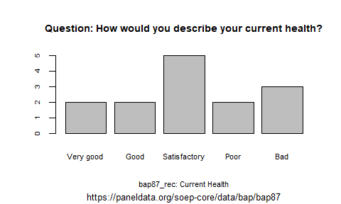

```r
barplot(
  table(
  factor(
    bap87_rec,
      labels = names(attributes(bap87_rec)$labels_en)
    )
  ),
  main = attributes(bap87_rec)$description_en, # title
  xlab = paste0(
    attributes(bap87_rec)$name, ": ", attributes(bap87_rec)$label), # label
  sub = attributes(bap87_rec)$url, # subtitle
  cex.main = 0.9, cex.names = 0.7, cex.sub = 0.8, cex.axis = 0.6,
  cex.lab = 0.7 # font sizes
)
```

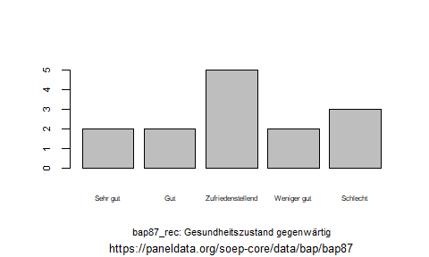

```r
barplot(
  table(
  factor(
    bap87_rec,
      labels = names(attributes(bap87_rec)$labels_de)
    )
  ),
  main = attributes(bap87_rec)$description_de, # title
  xlab = paste0(
    attributes(bap87_rec)$name, ": ", attributes(bap87_rec)$label_de), # label
  sub = attributes(bap87_rec)$url, # subtitle
  cex.main = 0.7, cex.names = 0.5, cex.sub = 0.8, cex.axis = 0.7,
  cex.lab = 0.7 # font sizes
)
```